# Advanced Bioinformatics 2025 assessment

m1200414

2025-03-25

### GENERAL R/STUDIO ASSESSMENT

## Task 3.1

```r
sum(5:55)
```

```
## [1] 1530
```

The : operator generates a sequence of all integers, as specified here between 5 and 55. The sum() function can then be used to calculate the sum of all these numbers.

## Task 3.2

```r
sumfun <- function(n) {sum(5:n)}
```

We create a function called sumfun. We identified n as the input parameter. We identified what we would like the function to do.

```r
sumfun(10)
```

```
## [1] 45
```

```r
sumfun(20)
```

```
## [1] 200
```

```r
sumfun(100)
```

```
## [1] 5040
```

We run the function for n = 10, n = 20, and n = 100. The respective results are presented here. For n = 10, the result is 45. For n = 20, the result is 200. For n = 100, the result is 5040.

## Task 3.3

We create a vector with 12 numbers, representing the 12 positions within the series.

```r
fibonacci_series <- numeric(12)
```

We define the first two steps in the sequence as 1, 1.

```r
fibonacci_series[1] <- 1
fibonacci_series[2] <- 1
```

We then use a “for” loop to calculate the remaining 10 numbers in the series (so position 3 to 12).

```r
for (i in 3:12) {
  fibonacci_series[i] <- fibonacci_series[i-1] + fibonacci_series[i-2]
}
```

We can then print the output.

```r
print(fibonacci_series)
```

```
##  [1]   1   1   2   3   5   8  13  21  34  55  89 144
```

## Task 3.4

First we install and load the required packages

```r
install.packages("ggplot2", dependencies = TRUE)
```

```
## Error in download.file(urls, destfiles, "libcurl", mode = "wb", ...) :
##   cannot open URL 'https://cloud.r-project.org/bin/windows/contrib/4.5/ggplot2_3.5.2.zip'
```

```r
library(ggplot2)
```

Then we load the dataset & review it

```r
data("mtcars")
View(mtcars)
```

Then we generate the boxplot with mpg on the y axis and number of gears on the x axis

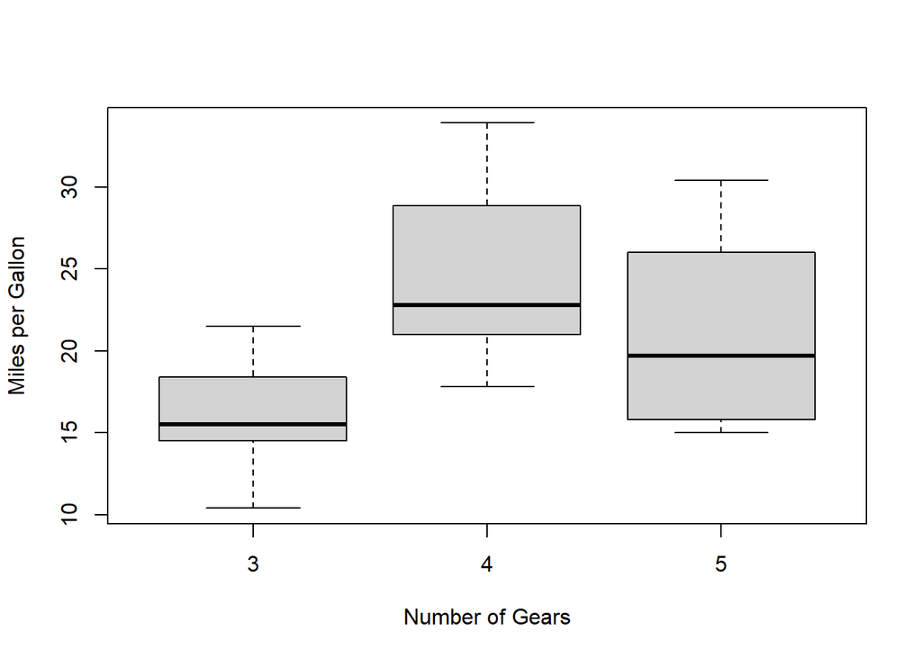

```r
boxplot(mtcars$mpg ~ mtcars$gear,
        xlab="Number of Gears",
        ylab="Miles per Gallon")
```

We can now add colour to the boxes

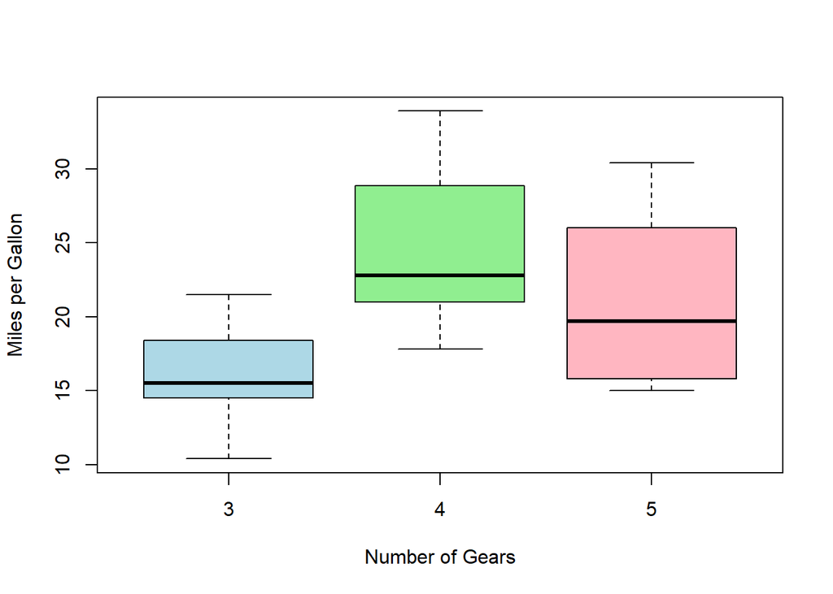

```r
boxplot(mtcars$mpg ~ mtcars$gear,
        xlab="Number of Gears",
        ylab="Miles per Gallon",
        col=c("lightblue", "lightgreen", "lightpink"))
```

## Task 3.5

First we load & view the cars dataset

```r
data(cars)
View(cars)
```

Then we define the object model1 & fit a linear relationship between speed and breaking distance.

```r
model1 <- lm(dist ~ speed, data = cars)
```

We can then use the summary to determine the fitted slops, and intercept of the line, and their standard errors.

```r
summary(model1)
```

```
##
## Call:
## lm(formula = dist ~ speed, data = cars)
##
## Residuals:
##     Min      1Q  Median      3Q     Max
## -29.069  -9.525  -2.272   9.215  43.201
##
## Coefficients:
##             Estimate Std. Error t value Pr(>|t|)
## (Intercept) -17.5791     6.7584  -2.601   0.0123 *
## speed         3.9324     0.4155   9.464 1.49e-12 ***
## ---
## Signif. codes:  0 '***' 0.001 '**' 0.01 '*' 0.05 '.' 0.1 ' ' 1
##
## Residual standard error: 15.38 on 48 degrees of freedom
## Multiple R-squared:  0.6511, Adjusted R-squared:  0.6438
## F-statistic: 89.57 on 1 and 48 DF,  p-value: 1.49e-12
```

This indicates that: Intercept: -17.5791 Standard error: 6.7584

Slope: 3.9324 Standard error: 0.4155

We can determine the units used for the variables in this dataset using the following command

```r
?cars
```

```
## starting httpd help server ... done
```

This indicates that speed is given in miles per hour and stopping distance is given in feet.

## Task 3.6

We use ggplot to plot the data points, using geom_point to show the data points themselves, and geom_smooth to show the line of linear relationship between the speed and stopping distance.

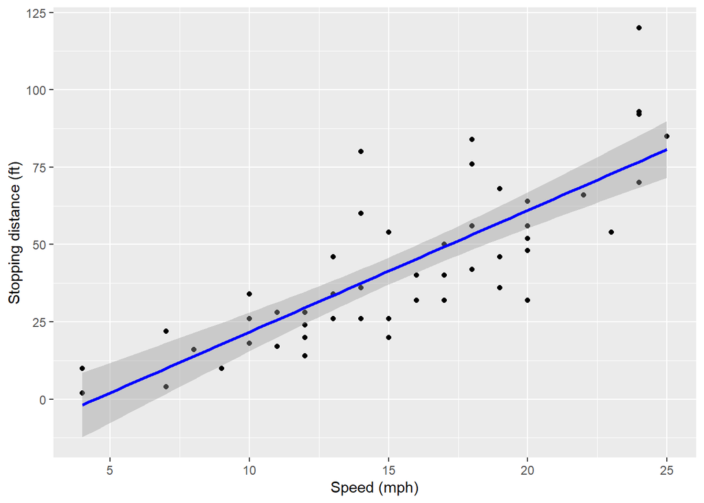

```r
ggplot(cars, aes(x = speed, y= dist)) +
    geom_point() +
    geom_smooth(method = "lm", colour = "blue") +
    labs(x= "Speed (mph)",
         y= "Stopping distance (ft)")
```

## Task 3.7

We want to know the reaction time in seconds. In order to ease the calculations, we should convert speed from miles per hour to feet per second. We create a new column with speed in feet per second. There are 5280 feet in a mile and 3600 seconds in an hour.

```r
cars$speed_fps <- cars$speed * (5280/3600)
```

The breaking distance once breaking starts is assumed to be proportional to the square of the speed. We can call this a. a = b * speed^2 where b is a constant of proportionality related to breaking distance once breaking starts.

The reaction distance is the relationship between reaction time and speed of travel. We can call this m. m = n * speed where n is the reaction time.

The total breaking distance can be called d. It is the sum of a and m. d = a + m d = (b * speed^2) + (n * speed)

We can divide the equation by the speed. d/speed = (b * speed^2)/speed + (n * speed)/speed d/speed = b * speed + n

We can therefore estimate n, the intercept of this linear regression equation, from the available data. We create a column outlining d/speed (distance in feet divided by speed in feet per second)

```r
cars$dist_over_speed <- cars$dist / cars$speed_fps
```

Now, we can fit a linear model of distance over speed, according to speed. And then view the summary data of this model estimating the reaction time (intercept).

```r
model2 <- lm(dist_over_speed ~ speed_fps, data = cars)
summary(model2)
```

```
##
## Call:
## lm(formula = dist_over_speed ~ speed_fps, data = cars)
##
## Residuals:
##     Min      1Q  Median      3Q     Max
## -0.9832 -0.4500 -0.1384  0.3034  2.1862
##
## Coefficients:
##             Estimate Std. Error t value Pr(>|t|)
## (Intercept)  0.86002    0.29021   2.963  0.00472 **
## speed_fps    0.04139    0.01216   3.402  0.00136 **
## ---
## Signif. codes:  0 '***' 0.001 '**' 0.01 '*' 0.05 '.' 0.1 ' ' 1
##
## Residual standard error: 0.6604 on 48 degrees of freedom
## Multiple R-squared:  0.1943, Adjusted R-squared:  0.1775
## F-statistic: 11.58 on 1 and 48 DF,  p-value: 0.001356
```

This suggests that the estimated reaction time is 0.86 seconds. This result appears to be reasonable, it is consistent with the literature, with a study by Dickerson et al. (2016) suggesting that reaction time ranges from 0.25 to 1.36 seconds).

We can then plot the data points using ggplot.

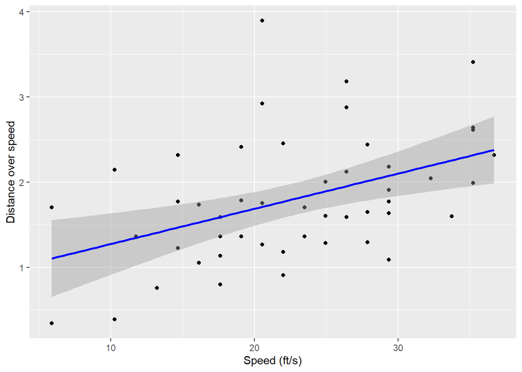

```r
ggplot(cars, aes(x=speed_fps, y=dist_over_speed)) +
    geom_point() +
    geom_smooth(method = "lm", colour = "blue") +
  labs (
    x = "Speed (ft/s)",
    y = "Distance over speed"
  )
```

To clarify, distance over speed (ft / (ft/s)), equates to time (total braking time) in seconds, so we can alter the labels of the graph to show this.

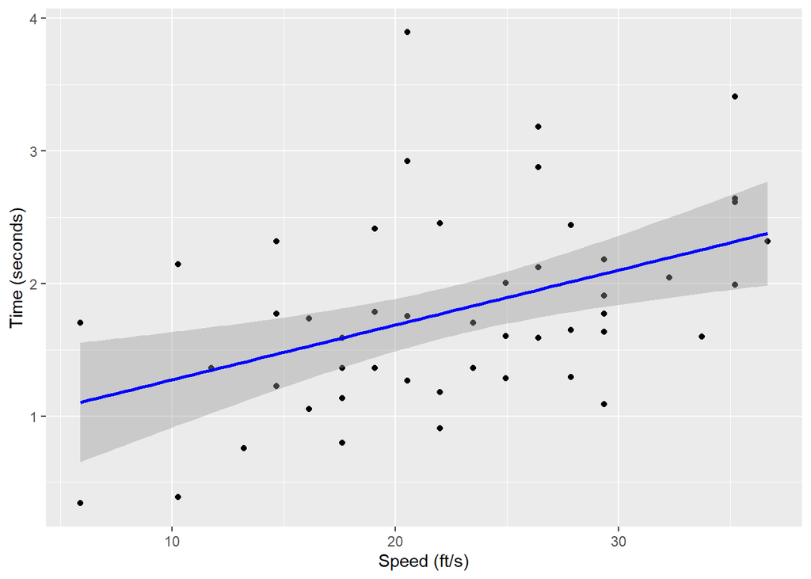

```r
ggplot(cars, aes(x=speed_fps, y=dist_over_speed)) +
    geom_point() +
    geom_smooth(method = "lm", colour = "blue") +
  labs (
    x = "Speed (ft/s)",
    y = "Time (seconds)"
  )
```

## Task 3.8

First, we install the packages that we require for the subsequent tasks & tasks in ChIPseq

```r
if (!requireNamespace("BiocManager", quietly = TRUE))
    install.packages("BiocManager")
BiocManager::install("DESeq2")
BiocManager::install("goseq")
BiocManager::install("RColorBrewer")
```

```r
BiocManager::install("pheatmap")
BiocManager::install("KEGG.db")
BiocManager::install("biomaRt")
BiocManager::install("org.Mm.eg.db")
BiocManager::install("ChIPseeker")
BiocManager::install("BSgenome.Mmusculus.UCSC.mm9")
BiocManager::install("ChIPQC")
install.packages("ggplot2",dependencies=TRUE)
install.packages("rmarkdown",dependencies=TRUE)
```

We load the relevant packages

```r
library(GenomeInfoDb)
library(GenomicRanges)
library(org.Mm.eg.db)
library(ChIPseeker)
library(BSgenome)
library(BSgenome.Mmusculus.UCSC.mm9)
library(DESeq2)
library(ChIPQC)
library(TxDb.Mmusculus.UCSC.mm9.knownGene)
```

Next, we set the working directory. Next, we read in the counts and the sample description

```r
setwd("C:\\Users\\tangu\\Downloads\\LMS_RNAseq_short-master-2023-final\\LMS_RNAseq_short-master-2023-final\\course\\exercises\\data")
all_counts <- read.csv("exercise1_counts.csv", header = T, row.names = 1)
sam_des <- read.table("exercise1_sample_description.info", header = TRUE, sep = "\t")
```

## Task 3.9

Next, we will create the col_data to prepare the data for DESeq

```r
col_data <- data.frame(sample = sam_des$sample, condition = sam_des$condition, batch = sam_des$batch)
col_data$sample <- as.factor(col_data$sample)
col_data$condition <- as.factor(col_data$condition)
col_data$batch <- as.factor(col_data$batch)
```

Next, we check dimensions

```r
all(colnames(all_counts) == col_data$name)
```

```
## [1] TRUE
```

## Task 3.10

First, we load the DESeq library

```r
library(DESeq2)
```

Then we create & view the DESeq object, then normalise it using DESeq

```r
dds <- DESeqDataSetFromMatrix(countData = all_counts, colData = col_data, design =~ condition)
dds
```

```
## class: DESeqDataSet
## dim: 26301 9
## metadata(1): version
## assays(1): counts
## rownames(26301): 497097 100503874 ... 100040384 100040400
## rowData names(0):
## colnames(9): control_FFa1.bam control_FFa2.bam ... mutant_KOb2.bam
##   mutant_KOb3.bam
## colData names(3): sample condition batch
```

```r
dds <- DESeq(dds)
```

## Task 3.11

For downstream analysis, we require the variance of gene expression to be more consistent across different expression levels. For this we can use rlog:

```r
rld <- rlog(dds)
```

Or we can use VST, which can be faster when working on large datasets:

```r
vsd <- varianceStabilizingTransformation(dds)
```

We get rld and vsd in count format, in order to view and inspect the result.

```r
rld_counts <- assay(rld)
vsd_counts <- assay(vsd)
View(rld_counts)
View(vsd_counts)
```

## Task 3.12

First we load the pheatmap library

```r
library("pheatmap")
```

Then we get the normalised dds counts

```r
dds_counts <- counts(dds, normalized = TRUE)
```

Then we select the top 40 highly expressed genes based on mean normalised counts

```r
mean_counts <- rowMeans(dds_counts)
select <- order(mean_counts, decreasing = TRUE)[1:40]
```

We then plot the heatmap using rld (rlog transformed data)

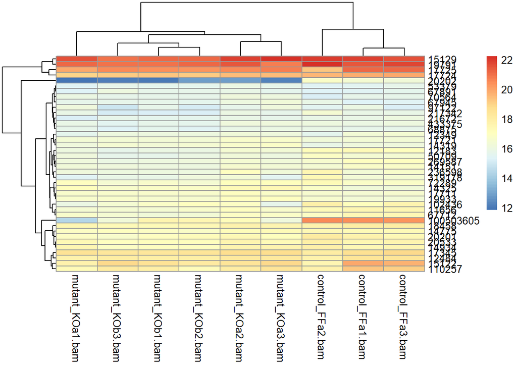

```r
pheatmap(rld_counts[select, ])
```

Alternatively, we can used the VST transformed data:

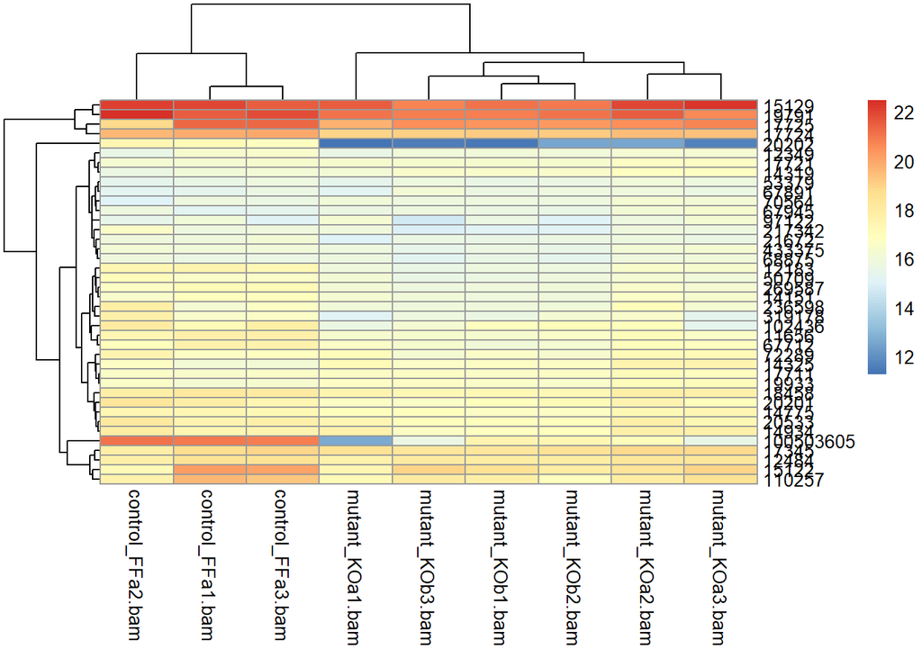

```r
pheatmap(vsd_counts[select, ])
```

## Task 3.13

We can then further explore our data using the Sample Distance Matrix, to see if biological replicates cluster together in separate groups. We will use the rlog for this.

```r
sample_dist <- dist(t(rld_counts))
sdm <- as.matrix(sample_dist)
```

We load the library to visualise this data

```r
library("RColorBrewer")
```

```r
rownames(sdm) <- rld$Group
colnames(sdm) <- NULL
colors <- colorRampPalette(rev(brewer.pal(9, "Blues")))(255)
```

We plot the heatmap to visualise the SDM

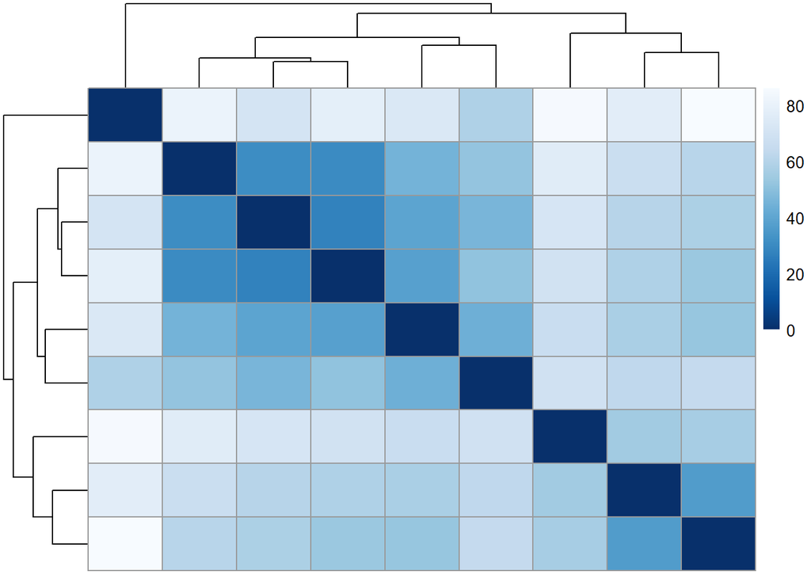

```r
pheatmap(sdm,
         clustering_distance_rows = sample_dist,
         clustering_distance_cols = sample_dist,
         col = colors)
```

## Task 3.14

We draw the PCA plot on the rlog transformed data

```
## using ntop=500 top features by variance
```

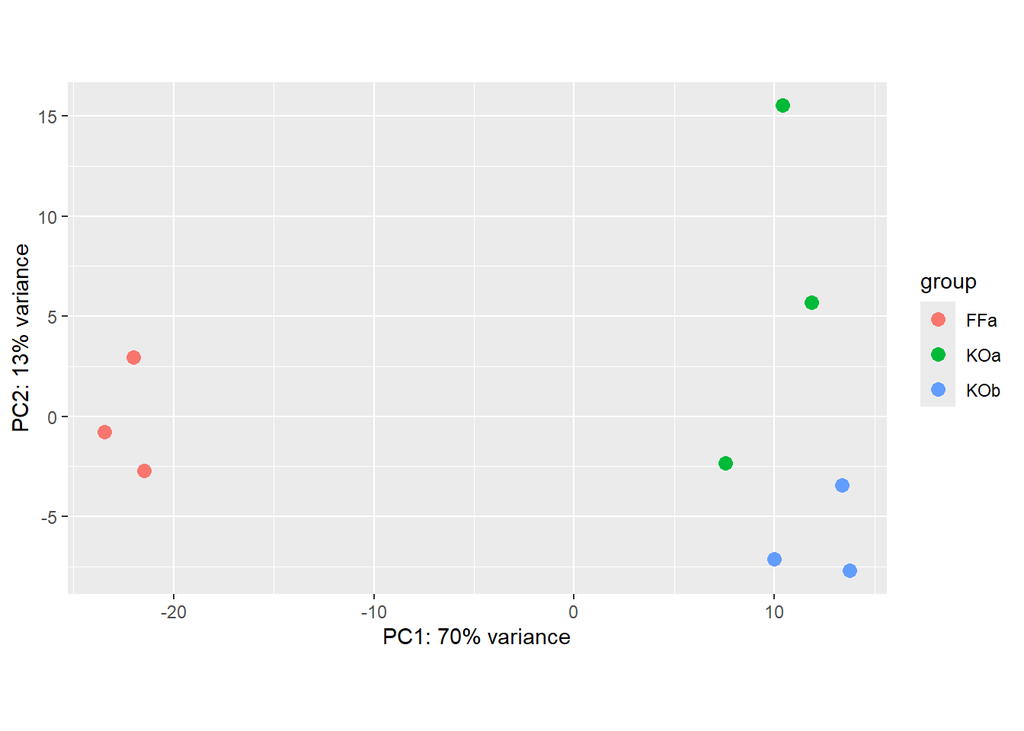

```r
plotPCA(rld, intgroup = "condition")
```

## Task 3.15

We can repeat the above step using the VST data

```
## using ntop=500 top features by variance
```

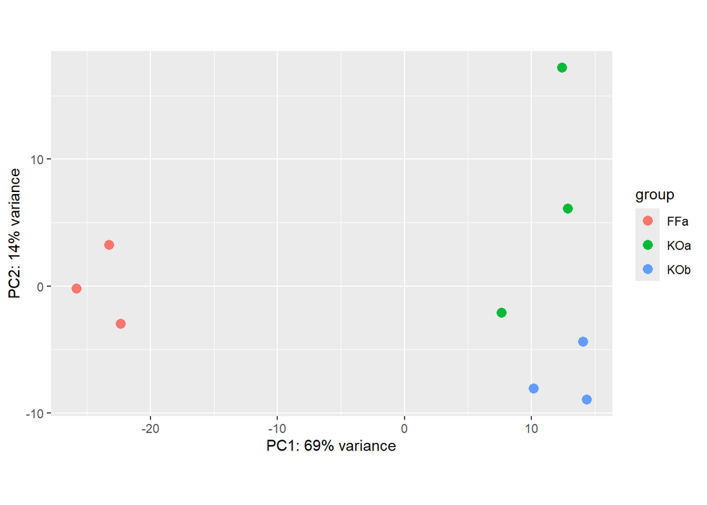

```r
plotPCA(vsd, intgroup = "condition")
```

## Task 3.16

We load the correct library

```r
library(GenomicRanges)
```

We set the working directory & read in the relevant datasets

```r
setwd("C:\\Users\\tangu\\Downloads\\LMS_ChIPseq_short-master-2023-final\\LMS_ChIPseq_short-master-2023-final\\course")
melPeak_Rep1 <- read.delim("data/MacsPeaks/mycmelrep1_peaks.xls",sep="\t",comment.char = "#")
melPeak_Rep2 <- read.delim("data/MacsPeaks/mycmelrep2_peaks.xls",sep="\t",comment.char = "#")
```

Next, for each dataset we creat an object which contains peak location using GRanges

```r
melRep1_GR <- GRanges(
                  seqnames=melPeak_Rep1[,"chr"],
                  IRanges(melPeak_Rep1[,"start"],
                  melPeak_Rep1[,"end"]
                  )
                )
```

Next we assign new metadata columns to specify the absolute summit position of the peak and the fold enrichment score.

```r
mcols(melRep1_GR) <- melPeak_Rep1[,c("abs_summit", "fold_enrichment")]
```

We repeat these steps for the second replicate

```r
melRep2_GR <- GRanges(
                  seqnames=melPeak_Rep2[,"chr"],
                  IRanges(melPeak_Rep2[,"start"],
                  melPeak_Rep2[,"end"]
                  )
                )

mcols(melRep2_GR) <- melPeak_Rep2[,c("abs_summit", "fold_enrichment")]
```

Finally, we generate the object commonMelPeaks which contains overlap between the two peaksets (the common peakset):

```r
commonMelPeaks <- melRep1_GR[melRep1_GR %over% melRep2_GR]
```

## Task 3.17

We can rank the common peakset by peak enrichment (from highest to lowest)

```r
ranked_peaks <- commonMelPeaks[order(commonMelPeaks$fold_enrichment, decreasing = TRUE), ]
```

Next, we select the top 500

```r
top_500_peaks <- head(ranked_peaks, 500)
```

Next we resized the peaks to 200bp around centre.

```r
top_500_peaks <- resize(top_500_peaks, 200, fix="center")
```

## Task 3.18

We define the genome object & format the top_500_peaks object

```r
genome <- BSgenome.Mmusculus.UCSC.mm9
seqlevelsStyle(top_500_peaks) <- "UCSC"
```

We use getSeq to give us the sequences under peaks

```r
commonPeaksSequences <- getSeq(genome,GRanges(top_500_peaks))
names(commonPeaksSequences) <- paste0("peak_",seqnames(top_500_peaks),"_",
                                        start(top_500_peaks),
                                        "-",
                                        end(top_500_peaks))
```

We extract this to FASTA file

```r
writeXStringSet(commonPeaksSequences,file="consensusPeaks.fa")
```

## Task 3.19

The resulting sequences were uploaded to MEME-ChIP